# First GMM

## k = 3

```r
q <- 3

priorsGMM3 <- list()
priorsGMM3$k <- q
priorsGMM3$lambda <- rep(1,q)
priorsGMM3$mu <- rep(0,q)
priorsGMM3$mu.sd <- rep(30,q)
priorsGMM3$sigma <- rep(2,q)
priorsGMM3$sigma.nu <- rep(0.125,q)

resGMM3 <- gibbsGMM(pcascore1vec, niter = 5000, nburn = 2000, priors = priorsGMM3)

clusteringGMM3 <-matrix(NA,max_number_of_pixels[1],max_number_of_pixels[2])
for(i in 1:dim(pixels)[1]){
  clusteringGMM3[pixels[i,1],pixels[i,2]] = which.max(resGMM3$alloc[i,])
}
print(table(clusteringGMM3))
```

```
## clusteringGMM3
##    1    2    3
## 8729 5824 3676
```

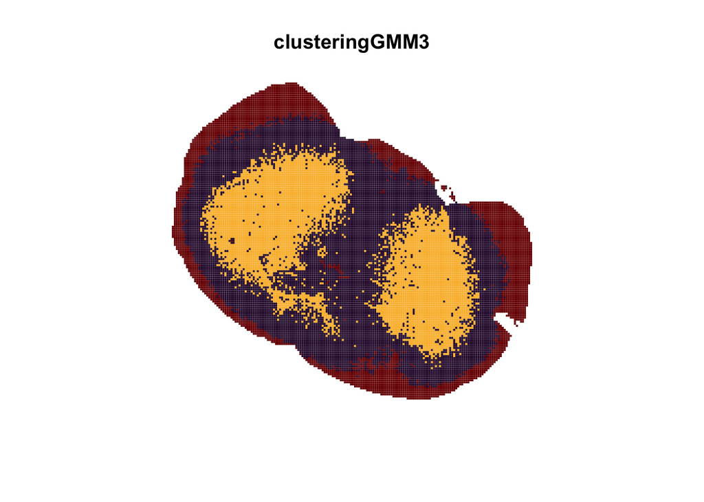

```r
par(mar=c(5.1, 4.1, 4.1, 4.1))
plot(clusteringGMM3, border=NA,asp = TRUE,col= turbo,axis.col=NULL, axis.row=NULL, xlab='', ylab='',key = NULL)
```

## K = 6

```r
q <- 6

priorsGMM6 <- list()
priorsGMM6$k <- q
priorsGMM6$lambda <- rep(1,q)
priorsGMM6$mu <- rep(0,q)
priorsGMM6$mu.sd <- rep(30,q)
priorsGMM6$sigma <- rep(2,q)
priorsGMM6$sigma.nu <- rep(0.125,q)

resGMM6 <- gibbsGMM(pcascore1vec, niter = 5000, nburn = 2000, priors = priorsGMM6)

clusteringGMM6 <-matrix(NA,max_number_of_pixels[1],max_number_of_pixels[2])
for(i in 1:dim(pixels)[1]){
  clusteringGMM6[pixels[i,1],pixels[i,2]] = which.max(resGMM6$alloc[i,])
}
print(table(clusteringGMM6))
```

```
## clusteringGMM6
##    1    2    3    4    5    6
## 1522  943 5384 1863 1118 7399
```

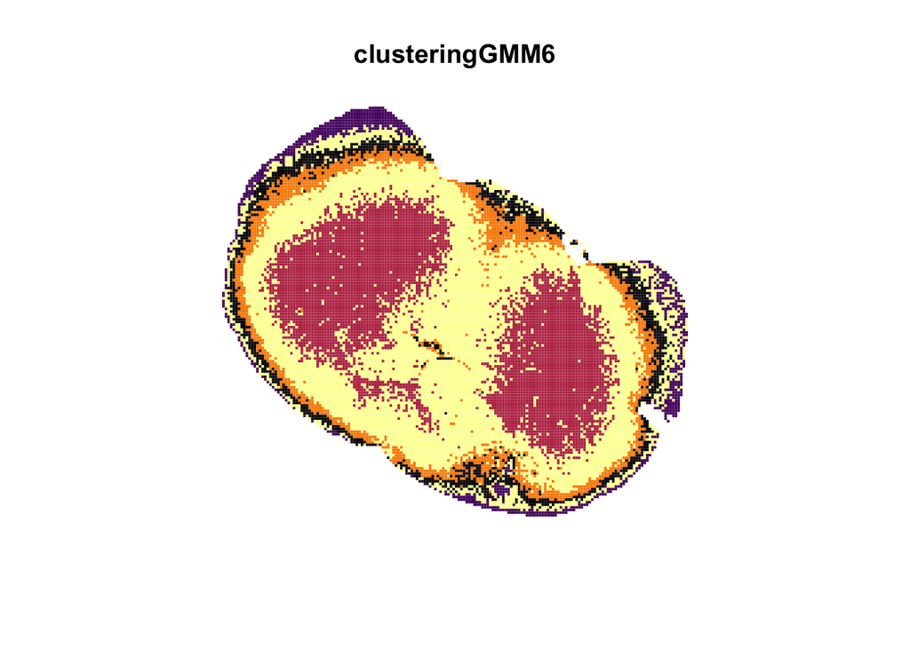

```r
par(mar=c(5.1, 4.1, 4.1, 4.1))
plot(clusteringGMM6, border=NA,asp = TRUE,col= inferno,axis.col=NULL, axis.row=NULL, xlab='', ylab='',key = NULL)
```

## K = 9

```r
q <- 9

priorsGMM9 <- list()
priorsGMM9$k <- q
priorsGMM9$lambda <- rep(1,q)
priorsGMM9$mu <- rep(1,q)
priorsGMM9$mu.sd <- rep(30,q)
priorsGMM9$sigma <- rep(2,q)
priorsGMM9$sigma.nu <- rep(0.125,q)

resGMM9 <- gibbsGMM(pcascore1vec, niter = 10000, nburn = 500, priors = priorsGMM9)

clusteringGMM9 <-matrix(NA,max_number_of_pixels[1],max_number_of_pixels[2])
for(i in 1:dim(pixels)[1]){
  clusteringGMM9[pixels[i,1],pixels[i,2]] = which.max(resGMM9$alloc[i,])
}
print(table(clusteringGMM9))
```

```
## clusteringGMM9
##    1    2    3    4    5    6    7    8    9
## 1633 2058  438  872 4407  966 1620  924 5311
```

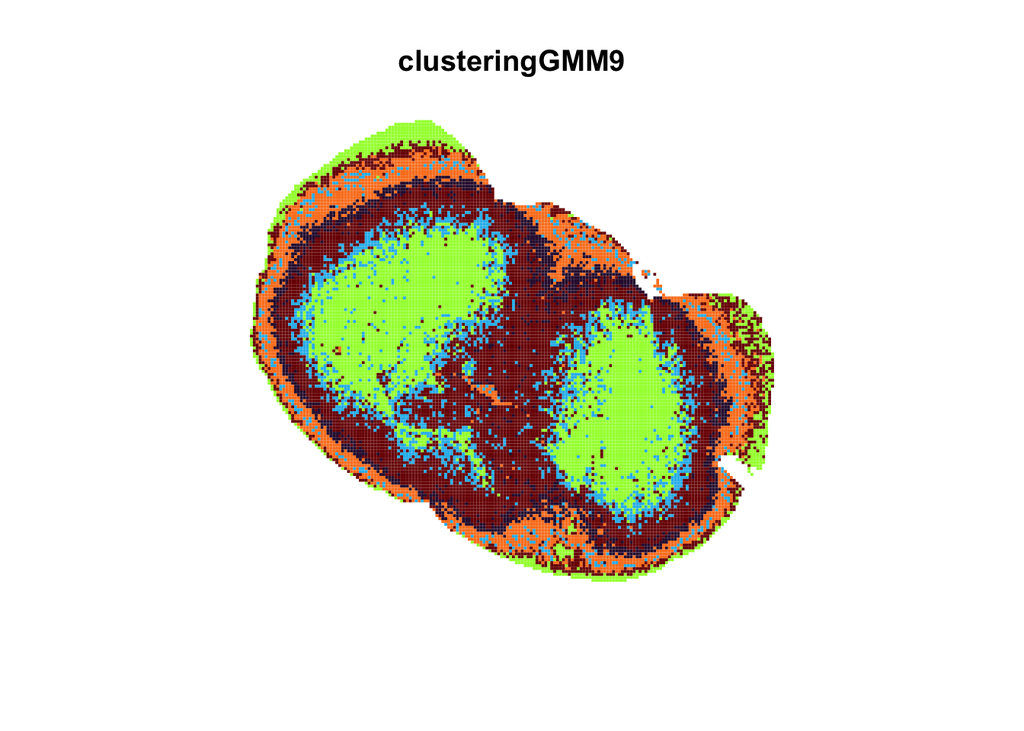

```r
par(mar=c(5.1, 4.1, 4.1, 4.1))
plot(clusteringGMM9, border=NA,asp = TRUE,col= turbo,axis.col=NULL, axis.row=NULL, xlab='', ylab='',key = NULL)
```

# more informative on the priors:

- the mu are more spread out in the range of possible values
- the variance of the mus is reduced to 10
- for the sigmas we keep the same as for the Dir parameter lambda

## k = 3

```r
q <- 3

priorsGMM3 <- list()
priorsGMM3$k <- q
priorsGMM3$lambda <- rep(1,q)
priorsGMM3$mu <- c(-15,0,15)
priorsGMM3$mu.sd <- rep(10,q)
priorsGMM3$sigma <- rep(2,q)
priorsGMM3$sigma.nu <- rep(0.125,q)

resGMM3 <- gibbsGMM(pcascore1vec, niter = 5000, nburn = 2000, priors = priorsGMM3)

clusteringGMM3 <-matrix(NA,max_number_of_pixels[1],max_number_of_pixels[2])
for(i in 1:dim(pixels)[1]){
  clusteringGMM3[pixels[i,1],pixels[i,2]] = which.max(resGMM3$alloc[i,])
}
print(table(clusteringGMM3))
```

```
## clusteringGMM3
##    1    2    3
## 5820 8720 3689
```

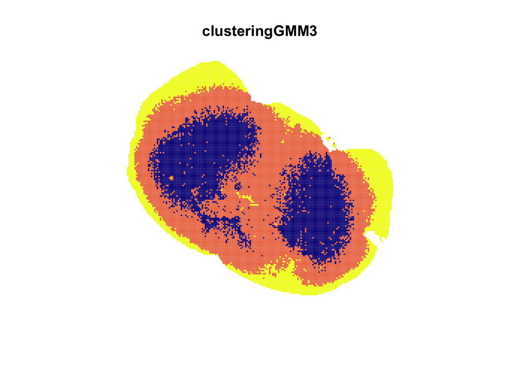

```r
par(mar=c(5.1, 4.1, 4.1, 4.1))
plot(clusteringGMM3, border=NA,asp = TRUE,col= plasma,axis.col=NULL, axis.row=NULL, xlab='', ylab='',key = NULL)
```

## K = 6

```r
q <- 6

priorsGMM6 <- list()
priorsGMM6$k <- q
priorsGMM6$lambda <- rep(1,q)
priorsGMM6$mu <- c(-23,-15,-7,0,7,15)
priorsGMM6$mu.sd <- rep(10,q)
priorsGMM6$sigma <- rep(2,q)
priorsGMM6$sigma.nu <- rep(0.125,q)

resGMM6 <- gibbsGMM(pcascore1vec, niter = 5000, nburn = 2000, priors = priorsGMM6)

clusteringGMM6 <-matrix(NA,max_number_of_pixels[1],max_number_of_pixels[2])
for(i in 1:dim(pixels)[1]){
  clusteringGMM6[pixels[i,1],pixels[i,2]] = which.max(resGMM6$alloc[i,])
}
print(table(clusteringGMM6))
```

```
## clusteringGMM6
##    1    2    3    4    5    6
## 5388 1130 7391  947 1846 1527
```

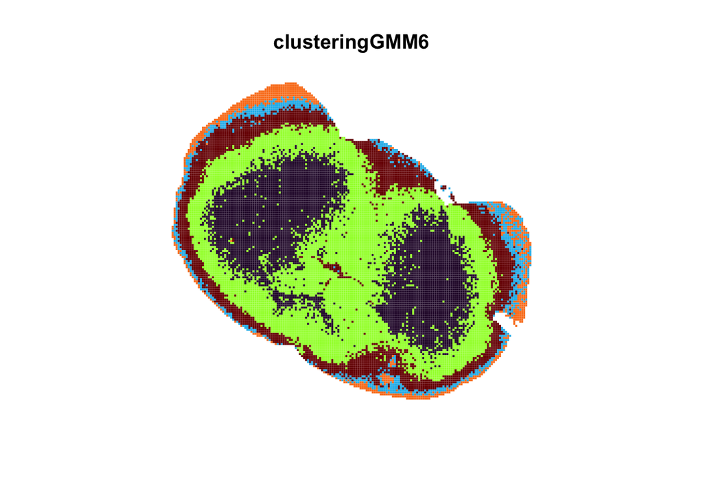

```r
par(mar=c(5.1, 4.1, 4.1, 4.1))
plot(clusteringGMM6,border=NA,asp = TRUE,col= turbo,axis.col=NULL, axis.row=NULL, xlab='', ylab='',key = NULL)
```

## K = 9

```r
q <- 9

priorsGMM9 <- list()
priorsGMM9$k <- q
priorsGMM9$lambda <- rep(1,q)
priorsGMM9$mu <- c(-25,-20,-15,-10,-5,0,5,10,15)
priorsGMM9$mu.sd <- rep(10,q)
priorsGMM9$sigma <- rep(2,q)
priorsGMM9$sigma.nu <- rep(0.125,q)

resGMM9 <- gibbsGMM(pcascore1vec, niter = 5000, nburn = 2000, priors = priorsGMM9)

clusteringGMM9 <-matrix(NA,max_number_of_pixels[1],max_number_of_pixels[2])
for(i in 1:dim(pixels)[1]){
  clusteringGMM9[pixels[i,1],pixels[i,2]] = which.max(resGMM9$alloc[i,])
}
print(table(clusteringGMM9))
```

```
## clusteringGMM9
##    1    2    3    4    5    6    7    8    9
## 1460 2550 1518 1125 1428 3940  889  985 4334
```

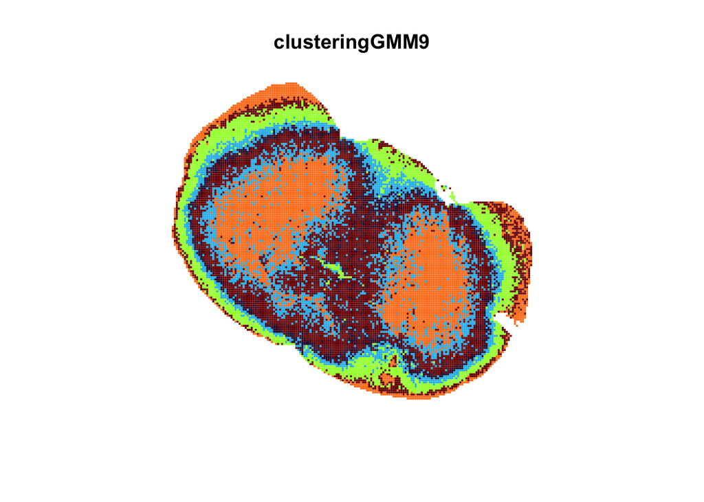

```r
par(mar=c(5.1, 4.1, 4.1, 4.1))
plot(clusteringGMM9, border=NA,asp = TRUE,col=turbo,axis.col=NULL, axis.row=NULL, xlab='', ylab='',key = NULL)
```

# questions:

- how do we chose k, can we take the values from the sparse finite mixture models? they will suggest from 3 to 7 af k
- how informative should we be with our priors and do the choices we have done make sense